# LSTM model of StockData

[Intro to LSTM](https://machinelearningmastery.com/gentle-introduction-long-short-term-memory-networks-experts/)

In this notebook we will go through a basic Long Short Term Memory (LSTM) model for time series. The notebooks does the following things:

- First load in the data. The preproccessing only consist of normalization and the creation of windows.
- Creation of the LSTM model
- Training the LSTM model
- Testing the LSTM model with 1 time step and with 1 window

## Importing libraries and loading in the data

### Import libraries

```python
import warnings
warnings.filterwarnings("ignore")
import tensorflow as tf
import re
import math
```

```python
import matplotlib.pyplot as plt
import statsmodels.tsa.seasonal as smt
import numpy as np # linear algebra
import pandas as pd # data processing, CSV file I/O (e.g. pd.read_csv)
import random
import datetime as dt
from sklearn import linear_model
from sklearn.metrics import mean_absolute_error
import plotly
import os
from subprocess import check_output

# import the relevant Keras modules
from keras.models import Sequential
from keras.layers import Activation, Dense
from keras.layers import LSTM
from keras.layers import Dropout
```

```python
# Use CPU to run the model
os.environ["CUDA_VISIBLE_DEVICES"]="-1"
```

### 1) Loading in the data

Select a stock or ETF for this HW from the ones available.

```python
filename = "ETFs\\adre.us.txt"#"<insert file name>"
print(filename)

df = pd.read_csv(filename, sep=",")
df['Label'] = filename
df['Date'] = pd.to_datetime(df['Date'])
df.head()
```

```
ETFs\adre.us.txt
```

|  | Date | Open | High | Low | Close | Volume | OpenInt | Label |
| --- | --- | --- | --- | --- | --- | --- | --- | --- |
| 0 | 2005-02-25 | 19.065 | 19.416 | 19.065 | 19.416 | 72019 | 0 | ETFs\adre.us.txt |
| 1 | 2005-02-28 | 20.172 | 20.172 | 19.312 | 19.380 | 101346 | 0 | ETFs\adre.us.txt |
| 2 | 2005-03-01 | 19.798 | 19.798 | 19.209 | 19.268 | 53671 | 0 | ETFs\adre.us.txt |
| 3 | 2005-03-02 | 19.109 | 19.195 | 19.042 | 19.160 | 23894 | 0 | ETFs\adre.us.txt |
| 4 | 2005-03-03 | 19.744 | 19.744 | 19.127 | 19.187 | 28870 | 0 | ETFs\adre.us.txt |

### Visualize the data

Plotly is a nice visualization library that has some interactive plot options.

```python
r = lambda: random.randint(0,255)
traces = []

#for df in data:
clr = str(r()) + str(r()) + str(r())
df = df.sort_values('Date')
label = df['Label'].iloc[0]

trace = plotly.graph_objs.Scattergl(
    x=df['Date'],
    y=df['Close']#,mode='line',line=dict(color = "blue")
)
traces.append(trace)

layout = plotly.graph_objs.Layout(
    title='Plot '+label.split(sep='.')[0].upper(),
)
fig = plotly.graph_objs.Figure(data=traces, layout=layout)

plotly.offline.init_notebook_mode(connected=True)
plotly.offline.iplot(fig, filename='dataplot')
```

[interactive chart not shown]

### 2) Creating windows and normalizing the data

The default window here is 10. The final question will ask you to consider this parameter in your final analysis and how it might impact your results.

```python
window_len = 10

#Create a data point (i.e. a date) which splits the training and testing set
split_date = list(df["Date"][-(2*window_len+1):])[0]
print("split_date:",split_date)


#Split the training and test set
training_set, test_set = df[df['Date'] < split_date], df[df['Date'] >= split_date]
training_set = training_set.drop(['Date','Label', 'OpenInt'], 1)
test_set = test_set.drop(['Date','Label','OpenInt'], 1)

#Create windows for training
LSTM_training_inputs = []
for i in range(len(training_set)-window_len):
    temp_set = training_set[i:(i+window_len)].copy()

    for col in list(temp_set):
        temp_set[col] = temp_set[col]/temp_set[col].iloc[0] - 1

    LSTM_training_inputs.append(temp_set)
LSTM_training_inputs
LSTM_training_outputs = (training_set['Close'][window_len:].values/training_set[
    'Close'][:-window_len].values)-1

LSTM_training_inputs = [np.array(LSTM_training_input) for LSTM_training_input in LSTM_training_inputs]
LSTM_training_inputs = np.array(LSTM_training_inputs)

# Create windows for testing
LSTM_test_inputs = []
for i in range(len(test_set)-window_len):
    temp_set = test_set[i:(i+window_len)].copy()

    for col in list(temp_set):
        temp_set[col] = temp_set[col]/temp_set[col].iloc[0] - 1

    LSTM_test_inputs.append(temp_set)
LSTM_test_outputs = (test_set['Close'][window_len:].values/test_set['Close'][:-window_len].values)-1

LSTM_test_inputs = [np.array(LSTM_test_inputs) for LSTM_test_inputs in LSTM_test_inputs]
LSTM_test_inputs = np.array(LSTM_test_inputs)
```

```
split_date: 2017-10-13 00:00:00
```

## 3) LSTM model definition

LSTM's have a set of parameters that can be tuned to your data set. Consider these inputs: **activation function, loss function, dropout rate, optimizer, nn layers/architecture** and review your options in the documentation.

[Keras Docs](https://keras.io/api/layers/recurrent_layers/lstm/)

```python
def build_model(inputs, output_size, neurons, activ_func="linear",
                dropout=0.10, loss="mae", optimizer="adam"):

    model = Sequential()

    model.add(LSTM(neurons, input_shape=(inputs.shape[1], inputs.shape[2])))
    model.add(Dropout(dropout))
    model.add(Dense(units=output_size))
    model.add(Activation(activ_func))

    model.compile(loss=loss, optimizer=optimizer)
    return model
```

## 4) Training of the LSTM model

Just like most ML models choosing a stopping condition is important. Here we use **Epochs** or iterations to set this stopping condition where we also monitor the loss at each step. Consider **Epochs** as a parameter to adjust.

```python
# initialise model architecture
nn_model = build_model(LSTM_training_inputs, output_size=1, neurons = 32)
# model output is next price normalised to 10th previous closing price
# train model on data
# note: eth_history contains information on the training error per epoch
nn_history = nn_model.fit(LSTM_training_inputs, LSTM_training_outputs,
                            epochs=5, batch_size=1, verbose=2, shuffle=True)
```

```
3170/3170 - 5s - loss: 0.0240 - 5s/epoch - 2ms/step
3170/3170 - 4s - loss: 0.0157 - 4s/epoch - 1ms/step
3170/3170 - 4s - loss: 0.0146 - 4s/epoch - 1ms/step
3170/3170 - 4s - loss: 0.0140 - 4s/epoch - 1ms/step
3170/3170 - 4s - loss: 0.0138 - 4s/epoch - 1ms/step
```

### Prediction of one window (n steps) ahead

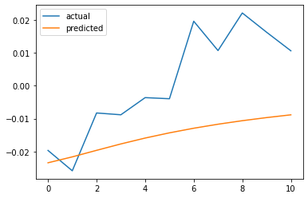

```
The Mean Absolute Error is: 0.016746579302144234
```

```python
def predict_sequence_full(model, data, window_size):
    #Shift the window by 1 new prediction each time, re-run predictions on new window
    curr_frame = data[0]
    predicted = []
    for i in range(len(data)):
        predicted.append(model.predict(curr_frame[np.newaxis,:,:])[0,0])
        curr_frame = curr_frame[1:]
        curr_frame = np.insert(curr_frame, [window_size-1], predicted[-1], axis=0)
    return predicted

predictions = predict_sequence_full(nn_model, LSTM_test_inputs, 10)

plt.plot(LSTM_test_outputs, label="actual")
plt.plot(predictions, label="predicted")
plt.legend()
plt.show()
MAE = mean_absolute_error(LSTM_test_outputs, predictions)
print('The Mean Absolute Error is: {}'.format(MAE))
```

## Conclusion

For this HW your task is to select a stock or ETF from the provided folder. You will run the code above with the default parameters and understand the logic and flow of the program. Once you are confident the code runs you are to test different parameter settings. You are to report the best set of parameters that you find and explain the importance of each parameter and how it impacts the training of the model. To best know how much to adjust and how to interpret the impacts I suggest changing one parameter at a at a time. This is a manual grid search you are performing so that you can become familiar with each parameter. In the future you can have grid search algorithms find the best set for you.

For each define the parameter and it's impact to the model. Report the set of values tested and the best parameter setting you found for each.

1) Window Length 2) LSTM Parameter: activation function 3) LSTM Parameter: loss function 4) LSTM Parameter: dropout rate 5) LSTM Parameter: optimizer 6) LSTM Parameter: nn layers/architecture 7) Epochs

The last cell has the questions 1-7 which expects a two part response, 2.pts each question, 1pt for the explanation of the parameter and 1 point for set of values tested with the best value for that particular parameters, this can be reported as an optimal set of parameters at the end. The 8th quest is submitted separately and asks you to perform back propagation on a simple NN for the final 1 pt. In all there are 15 points possible. Please download this notebook, import it into your workspace, download the stock or EFT in the files. You need to select one to train the NN on. Your completed HW should be a notebook with the optimal set of parameters and your answers in the last cell as markdown syntax. Then download the back propagation document and submit that answer as a separate document.

# Here are my answers to the above questions

```python
filename = "ETFs\\adre.us.txt"
df = pd.read_csv(filename, sep=",")
df['Label'] = filename
df['Date'] = pd.to_datetime(df['Date'])
df.head()
```

|  | Date | Open | High | Low | Close | Volume | OpenInt | Label |
| --- | --- | --- | --- | --- | --- | --- | --- | --- |
| 0 | 2005-02-25 | 19.065 | 19.416 | 19.065 | 19.416 | 72019 | 0 | ETFs\adre.us.txt |
| 1 | 2005-02-28 | 20.172 | 20.172 | 19.312 | 19.380 | 101346 | 0 | ETFs\adre.us.txt |
| 2 | 2005-03-01 | 19.798 | 19.798 | 19.209 | 19.268 | 53671 | 0 | ETFs\adre.us.txt |
| 3 | 2005-03-02 | 19.109 | 19.195 | 19.042 | 19.160 | 23894 | 0 | ETFs\adre.us.txt |
| 4 | 2005-03-03 | 19.744 | 19.744 | 19.127 | 19.187 | 28870 | 0 | ETFs\adre.us.txt |

```python
def build_model(inputs, output_size, neurons, activ_func="linear",
                dropout=0.10, loss="mae", optimizer="adam"):

    model = Sequential()

    model.add(LSTM(neurons, input_shape=(inputs.shape[1], inputs.shape[2])))
    model.add(Dropout(dropout))
    model.add(Dense(units=output_size))
    model.add(Activation(activ_func))

    model.compile(loss=loss, optimizer=optimizer)
    return model
```

## Window Length

```
split_date: 2017-11-08 00:00:00
3197/3197 - 3s - loss: 0.0125 - 3s/epoch - 839us/step
3197/3197 - 2s - loss: 0.0125 - 2s/epoch - 584us/step
3197/3197 - 2s - loss: 0.0125 - 2s/epoch - 622us/step
3197/3197 - 2s - loss: 0.0124 - 2s/epoch - 645us/step
3197/3197 - 2s - loss: 0.0124 - 2s/epoch - 617us/step
```

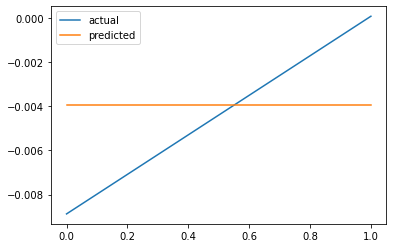

```
split_date: 2017-11-06 00:00:00
3194/3194 - 3s - loss: 0.0167 - 3s/epoch - 1ms/step
3194/3194 - 2s - loss: 0.0136 - 2s/epoch - 693us/step
3194/3194 - 2s - loss: 0.0132 - 2s/epoch - 771us/step
3194/3194 - 3s - loss: 0.0129 - 3s/epoch - 810us/step
3194/3194 - 2s - loss: 0.0129 - 2s/epoch - 746us/step
```

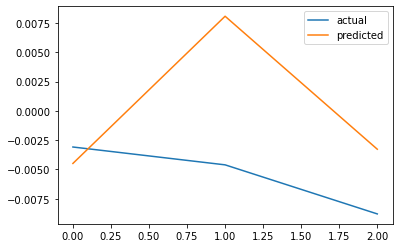

```
split_date: 2017-11-02 00:00:00
3191/3191 - 4s - loss: 0.0200 - 4s/epoch - 1ms/step
3191/3191 - 3s - loss: 0.0144 - 3s/epoch - 980us/step
3191/3191 - 3s - loss: 0.0135 - 3s/epoch - 996us/step
3191/3191 - 3s - loss: 0.0132 - 3s/epoch - 865us/step
3191/3191 - 3s - loss: 0.0131 - 3s/epoch - 885us/step
```

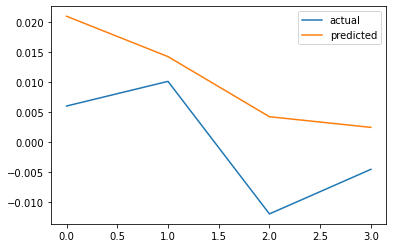

[output not shown]

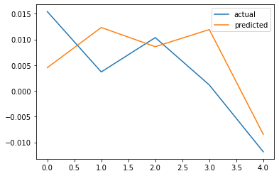

[output not shown]

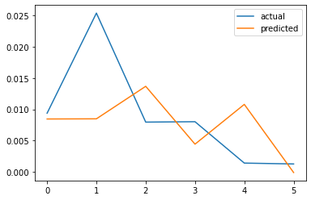

```
split_date: 2017-10-25 00:00:00
3182/3182 - 4s - loss: 0.0209 - 4s/epoch - 1ms/step
3182/3182 - 3s - loss: 0.0148 - 3s/epoch - 1ms/step
3182/3182 - 3s - loss: 0.0142 - 3s/epoch - 1ms/step
3182/3182 - 3s - loss: 0.0138 - 3s/epoch - 1ms/step
3182/3182 - 3s - loss: 0.0135 - 3s/epoch - 1ms/step
```

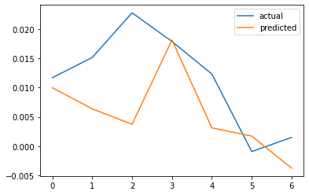

```
split_date: 2017-10-23 00:00:00
3179/3179 - 4s - loss: 0.0233 - 4s/epoch - 1ms/step
3179/3179 - 3s - loss: 0.0154 - 3s/epoch - 1ms/step
3179/3179 - 4s - loss: 0.0143 - 4s/epoch - 1ms/step
3179/3179 - 4s - loss: 0.0138 - 4s/epoch - 1ms/step
3179/3179 - 4s - loss: 0.0136 - 4s/epoch - 1ms/step
```

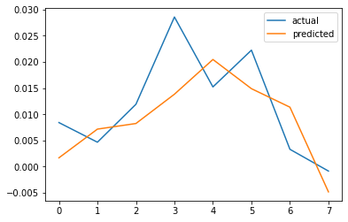

```
split_date: 2017-10-19 00:00:00
3176/3176 - 5s - loss: 0.0213 - 5s/epoch - 2ms/step
3176/3176 - 4s - loss: 0.0156 - 4s/epoch - 1ms/step
3176/3176 - 4s - loss: 0.0144 - 4s/epoch - 1ms/step
3176/3176 - 4s - loss: 0.0139 - 4s/epoch - 1ms/step
3176/3176 - 5s - loss: 0.0137 - 5s/epoch - 1ms/step
```

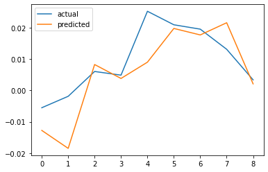

```
split_date: 2017-10-17 00:00:00
3173/3173 - 5s - loss: 0.0246 - 5s/epoch - 2ms/step
3173/3173 - 4s - loss: 0.0162 - 4s/epoch - 1ms/step
3173/3173 - 4s - loss: 0.0148 - 4s/epoch - 1ms/step
3173/3173 - 4s - loss: 0.0140 - 4s/epoch - 1ms/step
3173/3173 - 4s - loss: 0.0139 - 4s/epoch - 1ms/step
```

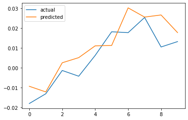

```
split_date: 2017-10-13 00:00:00
3170/3170 - 5s - loss: 0.0251 - 5s/epoch - 2ms/step
3170/3170 - 4s - loss: 0.0167 - 4s/epoch - 1ms/step
3170/3170 - 4s - loss: 0.0149 - 4s/epoch - 1ms/step
3170/3170 - 4s - loss: 0.0141 - 4s/epoch - 1ms/step
3170/3170 - 4s - loss: 0.0140 - 4s/epoch - 1ms/step
```

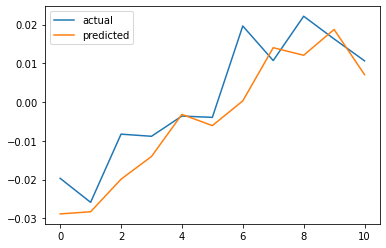

```
split_date: 2017-10-11 00:00:00
3167/3167 - 5s - loss: 0.0221 - 5s/epoch - 2ms/step
3167/3167 - 4s - loss: 0.0159 - 4s/epoch - 1ms/step
3167/3167 - 5s - loss: 0.0146 - 5s/epoch - 1ms/step
3167/3167 - 4s - loss: 0.0140 - 4s/epoch - 1ms/step
3167/3167 - 4s - loss: 0.0138 - 4s/epoch - 1ms/step
```

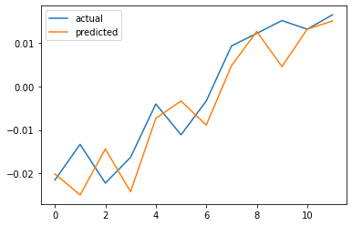

```
split_date: 2017-10-09 00:00:00
3164/3164 - 6s - loss: 0.0287 - 6s/epoch - 2ms/step
3164/3164 - 5s - loss: 0.0174 - 5s/epoch - 2ms/step
3164/3164 - 5s - loss: 0.0151 - 5s/epoch - 2ms/step
3164/3164 - 5s - loss: 0.0143 - 5s/epoch - 2ms/step
3164/3164 - 5s - loss: 0.0138 - 5s/epoch - 2ms/step
```

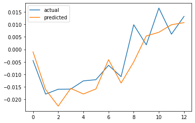

```
split_date: 2017-10-05 00:00:00
3161/3161 - 6s - loss: 0.0244 - 6s/epoch - 2ms/step
3161/3161 - 5s - loss: 0.0167 - 5s/epoch - 2ms/step
3161/3161 - 5s - loss: 0.0151 - 5s/epoch - 2ms/step
3161/3161 - 5s - loss: 0.0142 - 5s/epoch - 2ms/step
3161/3161 - 5s - loss: 0.0139 - 5s/epoch - 2ms/step
```

[7 more figures not shown]

```python
window_len_lst = list(range(1, 20))
window_dic = {}

for window_len in window_len_lst:
    split_date = list(df["Date"][-(2*window_len+1):])[0]
    print("split_date:",split_date)

    #Split the training and test set
    training_set, test_set = df[df['Date'] < split_date], df[df['Date'] >= split_date]
    training_set = training_set.drop(['Date','Label', 'OpenInt'], 1)
    test_set = test_set.drop(['Date','Label','OpenInt'], 1)

    #Create windows for training
    LSTM_training_inputs = []
    for i in range(len(training_set)-window_len):
        temp_set = training_set[i:(i+window_len)].copy()

        for col in list(temp_set):
            temp_set[col] = temp_set[col]/temp_set[col].iloc[0] - 1

        LSTM_training_inputs.append(temp_set)
    LSTM_training_inputs
    LSTM_training_outputs = (training_set['Close'][window_len:].values/training_set[
        'Close'][:-window_len].values)-1

    LSTM_training_inputs = [np.array(LSTM_training_input) for LSTM_training_input in LSTM_training_inputs]
    LSTM_training_inputs = np.array(LSTM_training_inputs)

    # Create windows for testing
    LSTM_test_inputs = []
    for i in range(len(test_set)-window_len):
        temp_set = test_set[i:(i+window_len)].copy()

        for col in list(temp_set):
            temp_set[col] = temp_set[col]/temp_set[col].iloc[0] - 1

        LSTM_test_inputs.append(temp_set)
    LSTM_test_outputs = (test_set['Close'][window_len:].values/test_set['Close'][:-window_len].values)-1

    LSTM_test_inputs = [np.array(LSTM_test_inputs) for LSTM_test_inputs in LSTM_test_inputs]
    LSTM_test_inputs = np.array(LSTM_test_inputs)

    # initialise model architecture
    nn_model = build_model(LSTM_training_inputs, output_size=1, neurons = 32)
    # model output is next price normalised to 10th previous closing price train model on data
    # note: eth_history contains information on the training error per epoch
    nn_history = nn_model.fit(LSTM_training_inputs, LSTM_training_outputs,
                                epochs=5, batch_size=1, verbose=2, shuffle=True)
    plt.plot(LSTM_test_outputs, label = "actual")
    plt.plot(nn_model.predict(LSTM_test_inputs), label = "predicted")
    plt.legend()
    plt.show()
    MAE = mean_absolute_error(LSTM_test_outputs, nn_model.predict(LSTM_test_inputs))
    window_dic[window_len] = MAE
window_result = pd.DataFrame(window_dic.values(), window_dic.keys()).rename(columns={0: "MAE"})
```

```
        MAE
1  0.004486
```

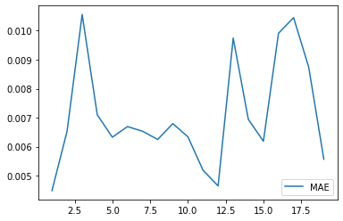

```python
print(window_result.loc[window_result["MAE"] == window_result["MAE"].min()])
window_result.plot()
```

The model parameter window denotes the number of days we use to trace back the prices, which hence represents the histrorical performance of the underlying asset.

It can be shown that using window = 1 would be the best choice with lowest mean absolute error, the result may due to the fact that, the price variation would not be so large between two consecutive trading days. We can observe from the plot that, the MAE firstly gets higher, then drops down and pulls up again.

## LSTM Parameter: activation function

```
split_date: 2017-10-13 00:00:00
3170/3170 - 5s - loss: 0.0365 - 5s/epoch - 2ms/step
3170/3170 - 4s - loss: 0.0364 - 4s/epoch - 1ms/step
3170/3170 - 4s - loss: 0.0364 - 4s/epoch - 1ms/step
3170/3170 - 5s - loss: 0.0364 - 5s/epoch - 1ms/step
3170/3170 - 4s - loss: 0.0364 - 4s/epoch - 1ms/step
```

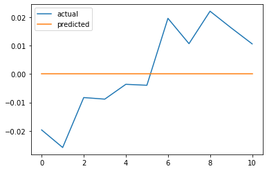

```
split_date: 2017-10-13 00:00:00
3170/3170 - 5s - loss: 0.0418 - 5s/epoch - 2ms/step
3170/3170 - 4s - loss: 0.0285 - 4s/epoch - 1ms/step
3170/3170 - 4s - loss: 0.0269 - 4s/epoch - 1ms/step
3170/3170 - 5s - loss: 0.0260 - 5s/epoch - 1ms/step
3170/3170 - 4s - loss: 0.0257 - 4s/epoch - 1ms/step
```

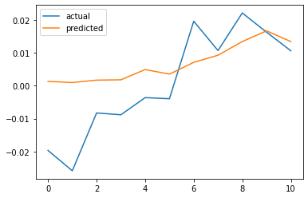

```
split_date: 2017-10-13 00:00:00
3170/3170 - 5s - loss: 0.9962 - 5s/epoch - 2ms/step
3170/3170 - 4s - loss: 0.9962 - 4s/epoch - 1ms/step
3170/3170 - 4s - loss: 0.9962 - 4s/epoch - 1ms/step
3170/3170 - 4s - loss: 0.9962 - 4s/epoch - 1ms/step
3170/3170 - 4s - loss: 0.9962 - 4s/epoch - 1ms/step
```

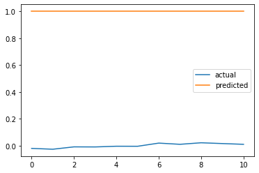

```
split_date: 2017-10-13 00:00:00
3170/3170 - 5s - loss: 0.0444 - 5s/epoch - 2ms/step
3170/3170 - 4s - loss: 0.0295 - 4s/epoch - 1ms/step
3170/3170 - 4s - loss: 0.0273 - 4s/epoch - 1ms/step
3170/3170 - 4s - loss: 0.0266 - 4s/epoch - 1ms/step
3170/3170 - 4s - loss: 0.0259 - 4s/epoch - 1ms/step
```

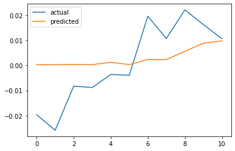

```
split_date: 2017-10-13 00:00:00
3170/3170 - 5s - loss: 0.0227 - 5s/epoch - 2ms/step
3170/3170 - 5s - loss: 0.0159 - 5s/epoch - 1ms/step
3170/3170 - 4s - loss: 0.0144 - 4s/epoch - 1ms/step
3170/3170 - 4s - loss: 0.0140 - 4s/epoch - 1ms/step
3170/3170 - 4s - loss: 0.0137 - 4s/epoch - 1ms/step
```

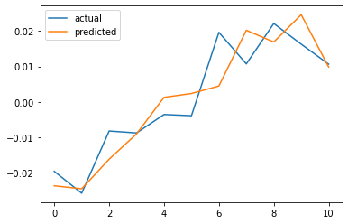

```
split_date: 2017-10-13 00:00:00
3170/3170 - 5s - loss: 0.0232 - 5s/epoch - 2ms/step
3170/3170 - 4s - loss: 0.0158 - 4s/epoch - 1ms/step
3170/3170 - 4s - loss: 0.0145 - 4s/epoch - 1ms/step
3170/3170 - 4s - loss: 0.0141 - 4s/epoch - 1ms/step
3170/3170 - 4s - loss: 0.0138 - 4s/epoch - 1ms/step
```

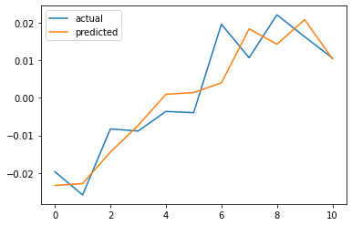

```
split_date: 2017-10-13 00:00:00
3170/3170 - 5s - loss: 0.0262 - 5s/epoch - 2ms/step
3170/3170 - 4s - loss: 0.0173 - 4s/epoch - 1ms/step
3170/3170 - 4s - loss: 0.0156 - 4s/epoch - 1ms/step
3170/3170 - 4s - loss: 0.0147 - 4s/epoch - 1ms/step
3170/3170 - 4s - loss: 0.0143 - 4s/epoch - 1ms/step
```

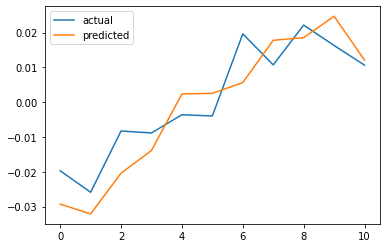

```
split_date: 2017-10-13 00:00:00
3170/3170 - 5s - loss: 0.0230 - 5s/epoch - 2ms/step
3170/3170 - 4s - loss: 0.0157 - 4s/epoch - 1ms/step
3170/3170 - 4s - loss: 0.0146 - 4s/epoch - 1ms/step
3170/3170 - 4s - loss: 0.0139 - 4s/epoch - 1ms/step
3170/3170 - 4s - loss: 0.0138 - 4s/epoch - 1ms/step
```

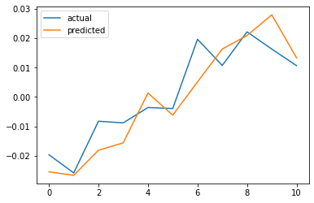

```
split_date: 2017-10-13 00:00:00
3170/3170 - 5s - loss: 0.0497 - 5s/epoch - 2ms/step
3170/3170 - 4s - loss: 0.0299 - 4s/epoch - 1ms/step
3170/3170 - 4s - loss: 0.0275 - 4s/epoch - 1ms/step
3170/3170 - 4s - loss: 0.0268 - 4s/epoch - 1ms/step
3170/3170 - 4s - loss: 0.0264 - 4s/epoch - 1ms/step
```

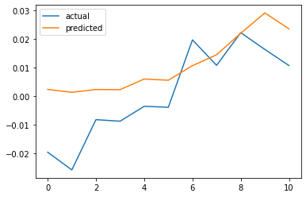

```
split_date: 2017-10-13 00:00:00
3170/3170 - 5s - loss: 0.0244 - 5s/epoch - 2ms/step
3170/3170 - 4s - loss: 0.0161 - 4s/epoch - 1ms/step
3170/3170 - 4s - loss: 0.0146 - 4s/epoch - 1ms/step
3170/3170 - 4s - loss: 0.0139 - 4s/epoch - 1ms/step
3170/3170 - 4s - loss: 0.0139 - 4s/epoch - 1ms/step
```

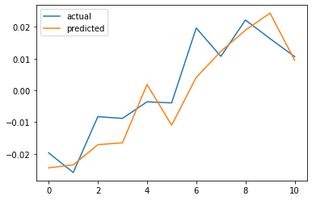

```python
activation_lst = ["relu", "sigmoid", "softmax", "softplus", "softsign",
                  "tanh", "selu", "elu", "exponential", "linear"]
activation_dic = {}

window_len = 10
for activation in activation_lst:
    def this_build_model(inputs, output_size, neurons, activ_func=activation,
                         dropout=0.10, loss="mae", optimizer="adam"):
        model = Sequential()

        model.add(LSTM(neurons, input_shape=(inputs.shape[1], inputs.shape[2])))
        model.add(Dropout(dropout))
        model.add(Dense(units=output_size))
        model.add(Activation(activ_func))

        model.compile(loss=loss, optimizer=optimizer)
        return model

    split_date = list(df["Date"][-(2*window_len+1):])[0]
    print("split_date:",split_date)

    #Split the training and test set
    training_set, test_set = df[df['Date'] < split_date], df[df['Date'] >= split_date]
    training_set = training_set.drop(['Date','Label', 'OpenInt'], 1)
    test_set = test_set.drop(['Date','Label','OpenInt'], 1)

    #Create windows for training
    LSTM_training_inputs = []
    for i in range(len(training_set)-window_len):
        temp_set = training_set[i:(i+window_len)].copy()

        for col in list(temp_set):
            temp_set[col] = temp_set[col]/temp_set[col].iloc[0] - 1

        LSTM_training_inputs.append(temp_set)
    LSTM_training_inputs
    LSTM_training_outputs = (training_set['Close'][window_len:].values/training_set[
        'Close'][:-window_len].values)-1

    LSTM_training_inputs = [np.array(LSTM_training_input) for LSTM_training_input in LSTM_training_inputs]
    LSTM_training_inputs = np.array(LSTM_training_inputs)

    # Create windows for testing
    LSTM_test_inputs = []
    for i in range(len(test_set)-window_len):
        temp_set = test_set[i:(i+window_len)].copy()

        for col in list(temp_set):
            temp_set[col] = temp_set[col]/temp_set[col].iloc[0] - 1

        LSTM_test_inputs.append(temp_set)
    LSTM_test_outputs = (test_set['Close'][window_len:].values/test_set['Close'][:-window_len].values)-1

    LSTM_test_inputs = [np.array(LSTM_test_inputs) for LSTM_test_inputs in LSTM_test_inputs]
    LSTM_test_inputs = np.array(LSTM_test_inputs)

    # initialise model architecture
    nn_model = this_build_model(LSTM_training_inputs, output_size=1, neurons = 32)
    # model output is next price normalised to 10th previous closing price train model on data
    # note: eth_history contains information on the training error per epoch
    nn_history = nn_model.fit(LSTM_training_inputs, LSTM_training_outputs,
                                epochs=5, batch_size=1, verbose=2, shuffle=True)
    plt.plot(LSTM_test_outputs, label = "actual")
    plt.plot(nn_model.predict(LSTM_test_inputs), label = "predicted")
    plt.legend()
    plt.show()
    MAE = mean_absolute_error(LSTM_test_outputs, nn_model.predict(LSTM_test_inputs))
    activation_dic[activation] = MAE
activation_result = pd.DataFrame(activation_dic.values(), activation_dic.keys()).rename(columns={0: "MAE"})
```

```
           MAE
tanh  0.005479
```

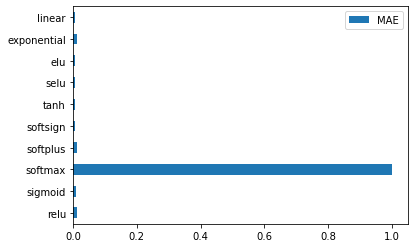

```python
print(activation_result.loc[activation_result["MAE"] == activation_result["MAE"].min()])
activation_result.plot(kind="barh")
```

We can observe that the `tanh` activation function has the lowest error, however, it doesn't vary a lot from other activation functions except for `softmax`, which has significantly higher error than other activation functions. This is becuase `softmax` function is a probabilistic function, and the vector returned by it would sum up to 1.

## LSTM Parameter: loss function

```
split_date: 2017-10-13 00:00:00
3170/3170 - 5s - loss: 0.0013 - 5s/epoch - 2ms/step
3170/3170 - 4s - loss: 5.4588e-04 - 4s/epoch - 1ms/step
3170/3170 - 4s - loss: 4.5618e-04 - 4s/epoch - 1ms/step
3170/3170 - 4s - loss: 4.3707e-04 - 4s/epoch - 1ms/step
3170/3170 - 4s - loss: 4.2026e-04 - 4s/epoch - 1ms/step
```

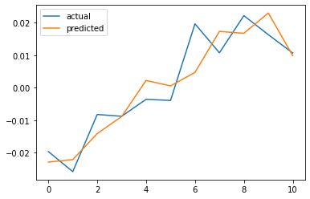

```
split_date: 2017-10-13 00:00:00
3170/3170 - 5s - loss: 0.0229 - 5s/epoch - 2ms/step
3170/3170 - 4s - loss: 0.0160 - 4s/epoch - 1ms/step
3170/3170 - 4s - loss: 0.0143 - 4s/epoch - 1ms/step
3170/3170 - 4s - loss: 0.0140 - 4s/epoch - 1ms/step
3170/3170 - 4s - loss: 0.0138 - 4s/epoch - 1ms/step
```

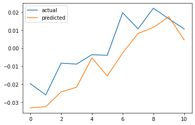

```
split_date: 2017-10-13 00:00:00
3170/3170 - 5s - loss: 153750.9375 - 5s/epoch - 2ms/step
3170/3170 - 5s - loss: 167885.2656 - 5s/epoch - 1ms/step
3170/3170 - 4s - loss: 135851.4844 - 4s/epoch - 1ms/step
3170/3170 - 4s - loss: 163576.8906 - 4s/epoch - 1ms/step
3170/3170 - 4s - loss: 143367.5156 - 4s/epoch - 1ms/step
```

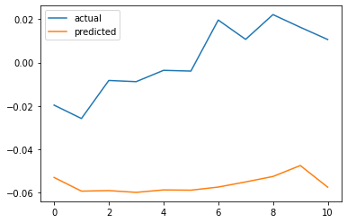

```
split_date: 2017-10-13 00:00:00
3170/3170 - 5s - loss: 7.2380e-04 - 5s/epoch - 2ms/step
3170/3170 - 4s - loss: 3.3209e-04 - 4s/epoch - 1ms/step
3170/3170 - 5s - loss: 2.2228e-04 - 5s/epoch - 1ms/step
3170/3170 - 4s - loss: 1.8553e-04 - 4s/epoch - 1ms/step
3170/3170 - 4s - loss: 1.6499e-04 - 4s/epoch - 1ms/step
```

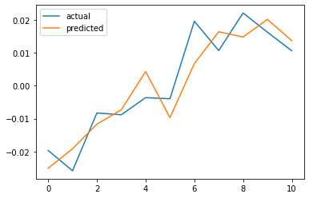

```
split_date: 2017-10-13 00:00:00
3170/3170 - 5s - loss: 0.0011 - 5s/epoch - 2ms/step
3170/3170 - 4s - loss: 3.6827e-04 - 4s/epoch - 1ms/step
3170/3170 - 4s - loss: 2.6161e-04 - 4s/epoch - 1ms/step
3170/3170 - 5s - loss: 2.1965e-04 - 5s/epoch - 1ms/step
3170/3170 - 5s - loss: 2.0357e-04 - 5s/epoch - 1ms/step
```

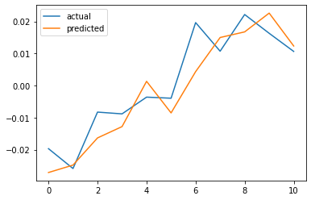

```python
loss_lst = ["mse", "mae", "mape", "msle", "huber"]
loss_dic = {}

window_len = 10
for loss in loss_lst:
    def this_build_model(inputs, output_size, neurons, activ_func="linear",
                         dropout=0.10, loss=loss, optimizer="adam"):
        model = Sequential()

        model.add(LSTM(neurons, input_shape=(inputs.shape[1], inputs.shape[2])))
        model.add(Dropout(dropout))
        model.add(Dense(units=output_size))
        model.add(Activation(activ_func))

        model.compile(loss=loss, optimizer=optimizer)
        return model

    split_date = list(df["Date"][-(2*window_len+1):])[0]
    print("split_date:",split_date)

    #Split the training and test set
    training_set, test_set = df[df['Date'] < split_date], df[df['Date'] >= split_date]
    training_set = training_set.drop(['Date','Label', 'OpenInt'], 1)
    test_set = test_set.drop(['Date','Label','OpenInt'], 1)

    #Create windows for training
    LSTM_training_inputs = []
    for i in range(len(training_set)-window_len):
        temp_set = training_set[i:(i+window_len)].copy()

        for col in list(temp_set):
            temp_set[col] = temp_set[col]/temp_set[col].iloc[0] - 1

        LSTM_training_inputs.append(temp_set)
    LSTM_training_inputs
    LSTM_training_outputs = (training_set['Close'][window_len:].values/training_set[
        'Close'][:-window_len].values)-1

    LSTM_training_inputs = [np.array(LSTM_training_input) for LSTM_training_input in LSTM_training_inputs]
    LSTM_training_inputs = np.array(LSTM_training_inputs)

    # Create windows for testing
    LSTM_test_inputs = []
    for i in range(len(test_set)-window_len):
        temp_set = test_set[i:(i+window_len)].copy()

        for col in list(temp_set):
            temp_set[col] = temp_set[col]/temp_set[col].iloc[0] - 1

        LSTM_test_inputs.append(temp_set)
    LSTM_test_outputs = (test_set['Close'][window_len:].values/test_set['Close'][:-window_len].values)-1

    LSTM_test_inputs = [np.array(LSTM_test_inputs) for LSTM_test_inputs in LSTM_test_inputs]
    LSTM_test_inputs = np.array(LSTM_test_inputs)

    # initialise model architecture
    nn_model = this_build_model(LSTM_training_inputs, output_size=1, neurons = 32)
    # model output is next price normalised to 10th previous closing price train model on data
    # note: eth_history contains information on the training error per epoch
    nn_history = nn_model.fit(LSTM_training_inputs, LSTM_training_outputs,
                                epochs=5, batch_size=1, verbose=2, shuffle=True)
    plt.plot(LSTM_test_outputs, label = "actual")
    plt.plot(nn_model.predict(LSTM_test_inputs), label = "predicted")
    plt.legend()
    plt.show()
    Error = mean_absolute_error(LSTM_test_outputs, nn_model.predict(LSTM_test_inputs))
    loss_dic[loss] = Error
loss_result = pd.DataFrame(loss_dic.values(), loss_dic.keys()).rename(columns={0: "Error"})
```

```
        Error
mse  0.005243
```

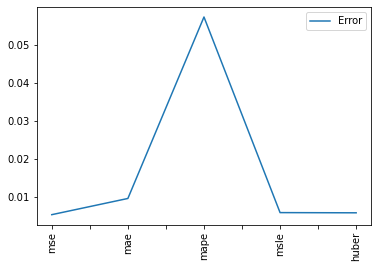

```python
print(loss_result.loc[loss_result["Error"] == loss_result["Error"].min()])
loss_result.plot(rot=90)
```

The loss function is the function that the model would seek to minimize during training. Here, the `mse` (Mean Squared Error) function would give us the lowest error value, however, this is becuase we used different measurement.